# Figure 1: Local mitochondrial enlargement and connectomics

# Fig 1C

Responses of juxtaspinal mitochondrial regions during single-spine plasticity.

**update for 2026 pending** — Spine-level replicate IDs are unavailable.

**Source data**  
`Fig 1C.csv`

**Columns**

- `Response` — Recruitment, protrusion, budding, or no change
- `spines` — Number of spines in the category

## Data

One row per response category.

```r
response_order <- c("recruitment", "protrusion", "budding", "no change")
Responses <- read_csv("./Fig 1C.csv", show_col_types = FALSE) %>%
  mutate(Response = factor(Response, levels = response_order), spines = as.integer(spines))
stopifnot(nrow(Responses) == 4, !anyNA(Responses), all(Responses$spines >= 0),
          !anyDuplicated(Responses$Response), sum(Responses$spines) > 0)
Responses
```

| Response | spines |
| --- | --- |
| recruitment | 11 |
| protrusion | 10 |
| budding | 2 |
| no change | 9 |

## Summary

```r
summary_table <- Responses %>% mutate(total_spines = sum(spines),
                                      Percent = 100 * spines / total_spines)
summary_table
```

| Response | spines | total_spines | Percent |
| --- | --- | --- | --- |
| recruitment | 11 | 32 | 34.375 |
| protrusion | 10 | 32 | 31.250 |
| budding | 2 | 32 | 6.250 |
| no change | 9 | 32 | 28.125 |

## Statistics

Descriptive counts and percentages.

## Plot

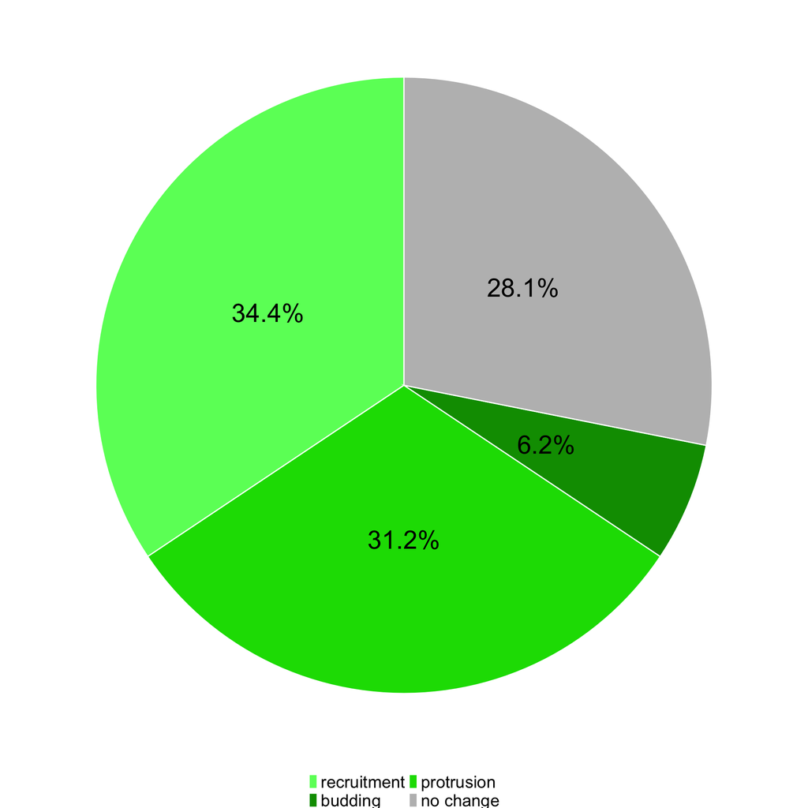

```r
set.seed(20261109)
fig1c_plot <- ggplot(summary_table, aes(x = 1, y = spines, fill = Response)) +
  geom_col(width = 1, color = "white", linewidth = 1) +
  geom_text(aes(label = paste0(round(Percent, 1), "%")),
            position = position_stack(vjust = 0.5), size = 16) +
  coord_polar(theta = "y") +
  scale_fill_manual(values = c("recruitment"="#66FF66", "protrusion"="#00DC00",
                               "budding"="#009A00", "no change"="#BDBDBD")) +
  guides(fill=guide_legend(nrow=2,byrow=TRUE)) +
  theme_void() + theme(plot.background=element_rect(fill="white",color=NA), legend.text = element_text(size = 30),
                      legend.title = element_blank(), legend.position = "bottom")
fig1c_plot
```

# Fig 1D (top)

Baseline area of juxtaspinal and non-juxtaspinal regions before single-spine plasticity induction.

**Source data**  
`Fig 1D.csv`

**Columns**

- `date` — Experiment date
- `condition` — Experimental condition
- `region` — Juxtaspinal or non-juxtaspinal region
- `dish` — Culture dish ID
- `cell` — Cell ID
- `spine` — Spine ID
- `time` — Time relative to induction (min)
- `mito_area_um2` — Mitochondrial area (µm²)

## Data

Baseline area is the mean of the complete −2, −1, and 0 min measurements for each region.

```r
region_order <- c("Juxta", "NonJuxta")
spacing_map <- c("Juxta" = 2.2, "NonJuxta" = 3.8)
Mito <- read_csv("./Fig 1D.csv", show_col_types = FALSE) %>%
  mutate(condition = trimws(as.character(condition)), region = factor(region, levels = region_order),
         date = trimws(as.character(date)),
         across(c(dish, cell, spine, time, mito_area_um2), as.numeric)) %>%
  filter(condition == "Control", !is.na(region), date != "", is.finite(time), is.finite(mito_area_um2))
if (nrow(Mito) == 0) stop("No valid observations remain.")
time_levels <- sort(unique(Mito$time))
if (length(time_levels) < 3) stop("Fewer than three time points were found.")

baseline_df <- Mito %>%
  mutate(time_order = match(time, time_levels), trace_id = paste(date, dish, cell, spine, sep = "_")) %>%
  filter(time_order <= 3) %>% group_by(date, condition, region, dish, cell, spine, trace_id) %>%
  summarise(baseline_mito_area = mean(mito_area_um2), n_timepoints = n_distinct(time_order), .groups = "drop") %>%
  filter(n_timepoints == 3, is.finite(baseline_mito_area)) %>%
  mutate(date = factor(date), date_region = paste(region, date, sep = "_"),
         x_pos = unname(spacing_map[as.character(region)]))
if (nrow(baseline_df) == 0) stop("No spines contain all three baseline time points.")
Mito %>% mutate(across(where(is.numeric), ~ round(.x, 3)))
```

| date | condition | region | dish | cell | spine | time | mito_area_um2 | norm_mito_area_um2 |
| --- | --- | --- | --- | --- | --- | --- | --- | --- |
| 2026-05-06 | Control | Juxta | 1 | 2 | 1 | -2 | 1.304 | 1.040 |
| 2026-05-06 | Control | Juxta | 1 | 2 | 1 | -1 | 1.204 | 0.960 |
| 2026-05-06 | Control | Juxta | 1 | 2 | 1 | 0 | 1.254 | 1.000 |
| 2026-05-06 | Control | Juxta | 1 | 2 | 1 | 2 | 1.184 | 0.944 |
| 2026-05-06 | Control | Juxta | 1 | 2 | 1 | 7 | 1.385 | 1.104 |
| 2026-05-06 | Control | Juxta | 1 | 2 | 1 | 12 | 1.395 | 1.112 |
| 2026-05-06 | Control | Juxta | 1 | 2 | 1 | 17 | 1.415 | 1.128 |
| 2026-05-06 | Control | Juxta | 1 | 2 | 1 | 22 | 1.244 | 0.992 |
| 2026-05-06 | Control | Juxta | 1 | 2 | 1 | 27 | 1.294 | 1.032 |
| 2026-05-06 | Control | Juxta | 1 | 2 | 1 | 32 | 1.314 | 1.048 |

[output cut: 982 more lines]

## Summary

```r
summary_table <- baseline_df %>% group_by(condition, region) %>%
  summarise(n_spines = n_distinct(trace_id), n_cells = n_distinct(date, dish, cell),
            n_Biological_Replicates = n_distinct(culture_id(date)),
            `Mean (SE)` = mean_se(baseline_mito_area), .groups = "drop")
summary_table
```

| condition | region | n_spines | n_cells | n_Biological_Replicates | Mean (SE) |
| --- | --- | --- | --- | --- | --- |
| Control | Juxta | 32 | 22 | 6 | 1.380 (0.108) |
| Control | NonJuxta | 30 | 21 | 6 | 1.026 (0.028) |

## Statistics

Two-way ANOVA with region, experiment date, and their interaction (Type I sums of squares).

```r
fit_aov <- aov(baseline_mito_area ~ region * date, data = baseline_df)
anova_table <- anova(fit_aov)
region_p <- as.numeric(anova_table["region", "Pr(>F)"])
interaction_p <- as.numeric(anova_table["region:date", "Pr(>F)"])
group_means <- baseline_df %>% group_by(region) %>%
  summarise(mean = mean(baseline_mito_area), se = sd(baseline_mito_area) / sqrt(n()), .groups = "drop")
stats_table <- tibble(
  Test = "Two-way ANOVA", Comparison = "Control Juxta vs Control NonJuxta",
  `Juxta mean (SE)` = sprintf("%.3f (%.3f)", group_means$mean[1], group_means$se[1]),
  `NonJuxta mean (SE)` = sprintf("%.3f (%.3f)", group_means$mean[2], group_means$se[2]),
  `Region p` = format_p(region_p), `Region x Date p` = format_p(interaction_p)
)
stats_table
```

| Test | Comparison | Juxta mean (SE) | NonJuxta mean (SE) | Region p | Region x Date p |
| --- | --- | --- | --- | --- | --- |
| Two-way ANOVA | Control Juxta vs Control NonJuxta | 1.380 (0.108) | 1.026 (0.028) | 0.0037 | 0.5522 |

## Plot

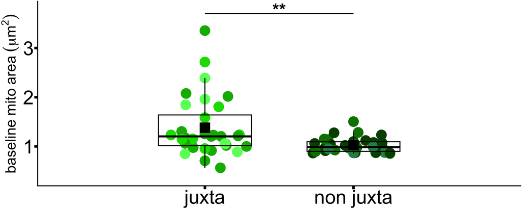

```r
set.seed(20261109)
test_results <- tibble(group1_x = 2.2, group2_x = 3.8, y_position = 3.7,
                       stars = p_to_stars(region_p)) %>% filter(stars != "ns")
date_levels <- levels(baseline_df$date)
date_region_colors <- c(
  setNames(rep(c("#00B400", "#00DC00", "#66FF66"), length.out = length(date_levels)), paste("Juxta", date_levels, sep = "_")),
  setNames(rep(c("#004D00", "#008000", "#2E8B57"), length.out = length(date_levels)), paste("NonJuxta", date_levels, sep = "_"))
)
fig1d_top_plot <- ggplot(baseline_df, aes(x_pos, baseline_mito_area, color = date_region)) +
  ggbeeswarm::geom_beeswarm(cex = 5, priority = "random", size = 20, alpha = 1, corral = "random") +
  geom_boxplot(aes(group = x_pos), fill = NA, width = 1, outlier.shape = NA, linewidth = 2, color = "black") +
  stat_summary(aes(group = x_pos), fun = mean, geom = "point", shape = 15, size = 20, color = "black") +
  geom_segment(data = test_results, aes(x = group1_x, xend = group2_x, y = y_position, yend = y_position),
               inherit.aes = FALSE, linewidth = 2, color = "black") +
  geom_text(data = test_results, aes(x = (group1_x + group2_x) / 2, y = y_position + 0.08, label = stars),
            inherit.aes = FALSE, size = 25, color = "black", fontface = "bold") +
  scale_x_continuous(oob = scales::oob_keep, breaks = unname(spacing_map), labels = c("juxta", "non juxta"),
                     limits = c(0.4, 5.6), expand = c(0, 0)) +
  scale_color_manual(values = date_region_colors) +
  scale_y_continuous(oob = scales::oob_keep, breaks = c(1, 2, 3), limits = c(0.2, 3.95), expand = c(0, 0)) +
  labs(x = NULL, y = expression(baseline~mito~area~group("(", mu*m^2, ")"))) +
  figure_theme(60, 80)
fig1d_top_plot
```

# Fig 1D (bottom)

Time course of juxtaspinal and non-juxtaspinal mitochondrial area after single-spine plasticity induction.

**Source data**  
`Fig 1D.csv`

**Columns**

- `date` — Experiment date
- `condition` — Experimental condition
- `region` — Juxtaspinal or non-juxtaspinal region
- `dish` — Culture dish ID
- `cell` — Cell ID
- `spine` — Spine ID
- `time` — Time relative to induction (min)
- `mito_area_um2` — Mitochondrial area (µm²)
- `norm_mito_area_um2` — Baseline-normalized mitochondrial area (unitless)

## Data

Tests use raw area. The time course shows area relative to baseline.

```r
region_order <- c("Juxta", "NonJuxta")
Mito <- read_csv("./Fig 1D.csv", show_col_types = FALSE) %>%
  mutate(condition = trimws(as.character(condition)), region = factor(region, levels = region_order),
         date = trimws(as.character(date)),
         across(c(dish, cell, spine, time, mito_area_um2, norm_mito_area_um2), as.numeric)) %>%
  filter(condition == "Control", !is.na(region), date != "", is.finite(time))
Mito %>% mutate(across(where(is.numeric), ~ round(.x, 3)))
```

| date | condition | region | dish | cell | spine | time | mito_area_um2 | norm_mito_area_um2 |
| --- | --- | --- | --- | --- | --- | --- | --- | --- |
| 2026-05-06 | Control | Juxta | 1 | 2 | 1 | -2 | 1.304 | 1.040 |
| 2026-05-06 | Control | Juxta | 1 | 2 | 1 | -1 | 1.204 | 0.960 |
| 2026-05-06 | Control | Juxta | 1 | 2 | 1 | 0 | 1.254 | 1.000 |
| 2026-05-06 | Control | Juxta | 1 | 2 | 1 | 2 | 1.184 | 0.944 |
| 2026-05-06 | Control | Juxta | 1 | 2 | 1 | 7 | 1.385 | 1.104 |
| 2026-05-06 | Control | Juxta | 1 | 2 | 1 | 12 | 1.395 | 1.112 |
| 2026-05-06 | Control | Juxta | 1 | 2 | 1 | 17 | 1.415 | 1.128 |
| 2026-05-06 | Control | Juxta | 1 | 2 | 1 | 22 | 1.244 | 0.992 |
| 2026-05-06 | Control | Juxta | 1 | 2 | 1 | 27 | 1.294 | 1.032 |
| 2026-05-06 | Control | Juxta | 1 | 2 | 1 | 32 | 1.314 | 1.048 |

[output cut: 982 more lines]

## Summary

```r
summary_table <- Mito %>% group_by(condition, region) %>%
  summarise(n_spines = n_distinct(date, dish, cell, spine),
            n_Biological_Replicates = n_distinct(culture_id(date)), .groups = "drop")
summary_table
```

| condition | region | n_spines | n_Biological_Replicates |
| --- | --- | --- | --- |
| Control | Juxta | 32 | 6 |
| Control | NonJuxta | 30 | 6 |

## Statistics

Repeated-measures ANOVA within region on raw area, with Greenhouse–Geisser correction and Tukey-adjusted period comparisons.

```r
time_levels <- sort(unique(Mito$time))
block_levels <- c("Baseline", "Post1", "Post2")
if (length(time_levels) < 16) stop("At least 16 time points are required.")
range_label <- function(x) paste0(min(x), "-", max(x))
block_ranges <- c(Baseline = range_label(time_levels[1:3]),
                  Post1 = range_label(time_levels[4:6]), Post2 = range_label(time_levels[7:16]))
block_data <- Mito %>%
  mutate(time_order = match(time, time_levels),
         time_block = case_when(time_order <= 3 ~ "Baseline", time_order <= 6 ~ "Post1", time_order <= 16 ~ "Post2"),
         trace_id = paste(date, dish, cell, spine, sep = "_")) %>%
  filter(!is.na(time_block), is.finite(mito_area_um2)) %>%
  group_by(region, trace_id, time_block) %>%
  summarise(mito_area_um2 = mean(mito_area_um2), .groups = "drop") %>%
  mutate(time_block = factor(time_block, levels = block_levels))

stats_results <- list()
for (region_name in region_order) {
  region_data <- block_data %>% filter(region == region_name) %>% select(trace_id, time_block, mito_area_um2)
  complete_ids <- region_data %>% count(trace_id) %>% filter(n == 3) %>% pull(trace_id)
  region_data <- region_data %>% filter(trace_id %in% complete_ids) %>% mutate(trace_id = factor(trace_id))
  if (n_distinct(region_data$trace_id) < 2) next
  rm_aov <- suppressMessages(afex::aov_ez(id = "trace_id", dv = "mito_area_um2", within = "time_block",
                                         data = region_data, anova_table = list(correction = "GG")))
  emmeans_table <- emmeans::emmeans(rm_aov, ~ time_block)
  means <- as.data.frame(emmeans_table)
  comparisons <- as.data.frame(emmeans::contrast(emmeans_table, "pairwise", adjust = "tukey")) %>%
    filter(grepl("^Baseline - ", contrast)) %>% mutate(compared_block = sub("^Baseline - ", "", contrast))
  baseline_index <- match("Baseline", means$time_block)
  block_index <- match(comparisons$compared_block, means$time_block)
  stats_results[[region_name]] <- tibble(
    region = region_name, compared_block = comparisons$compared_block,
    `Baseline mean (SE)` = sprintf("%.3f (%.3f)", means$emmean[baseline_index], means$SE[baseline_index]),
    `Compared mean (SE)` = sprintf("%.3f (%.3f)", means$emmean[block_index], means$SE[block_index]),
    anova_p = as.numeric(rm_aov$anova_table[["Pr(>F)"]][1]), p_value = comparisons$p.value
  )
}
posthoc_df <- bind_rows(stats_results)
if (nrow(posthoc_df) == 0) stop("No region had at least two complete spines.")
stats_table <- posthoc_df %>% transmute(
  condition = "Control", region, Test = "Repeated-measures ANOVA with Tukey post hoc",
  Comparison = paste(block_ranges["Baseline"], "vs", block_ranges[compared_block]),
  `Baseline mean (SE)`, `Compared mean (SE)`,
  `ANOVA p` = format_p(anova_p), `Tukey p` = format_p(p_value)
)
stats_table
```

| condition | region | Test | Comparison | Baseline mean (SE) | Compared mean (SE) | ANOVA p | Tukey p |
| --- | --- | --- | --- | --- | --- | --- | --- |
| Control | Juxta | Repeated-measures ANOVA with Tukey post hoc | -2-0 vs 2-12 | 1.380 (0.108) | 1.442 (0.102) | 0.0023 | 0.0758 |
| Control | Juxta | Repeated-measures ANOVA with Tukey post hoc | -2-0 vs 17-62 | 1.380 (0.108) | 1.483 (0.097) | 0.0023 | 0.0062 |
| Control | NonJuxta | Repeated-measures ANOVA with Tukey post hoc | -2-0 vs 2-12 | 1.026 (0.028) | 1.001 (0.034) | 0.4693 | 0.6087 |
| Control | NonJuxta | Repeated-measures ANOVA with Tukey post hoc | -2-0 vs 17-62 | 1.026 (0.028) | 0.999 (0.039) | 0.4693 | 0.7561 |

## Plot

The red bar marks single-spine induction from 0 to 2 min.

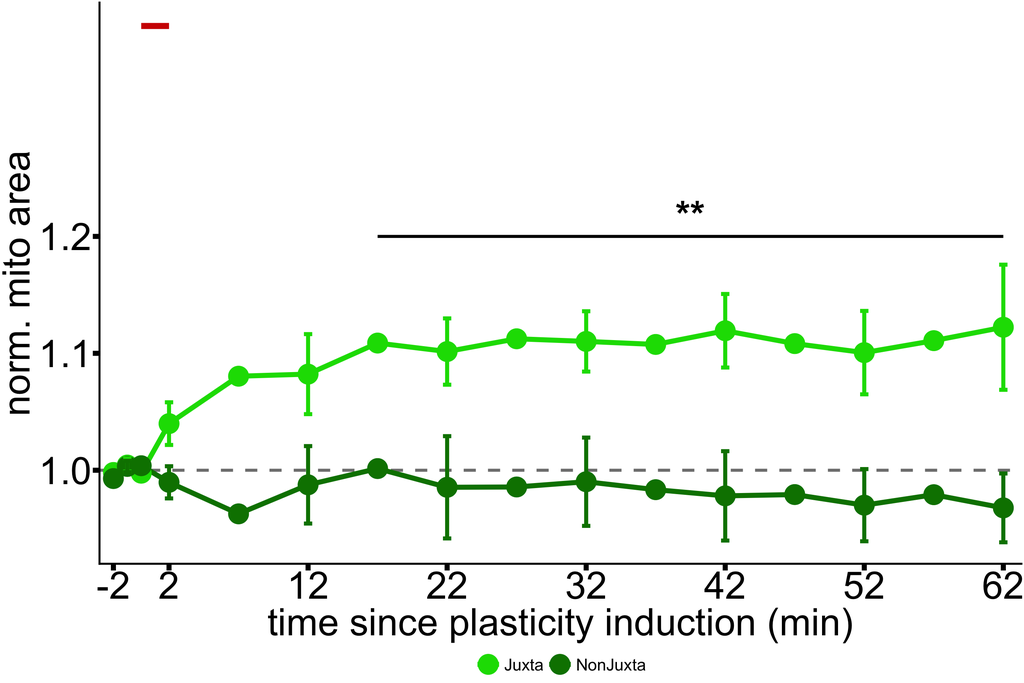

```r
set.seed(20261109)
region_colors <- c(Juxta = "#00DC00", NonJuxta = "#008000")
norm_summary <- Mito %>% mutate(time_order = match(time, time_levels)) %>%
  group_by(region, time, time_order) %>%
  summarise(mean_value = mean(norm_mito_area_um2, na.rm = TRUE),
            sd = sd(norm_mito_area_um2, na.rm = TRUE),
            n = sum(is.finite(norm_mito_area_um2)), sem = sd / sqrt(n), .groups = "drop") %>%
  filter(n > 0, is.finite(mean_value))
errorbars <- norm_summary %>% filter(time_order %% 2 == 0, is.finite(sem))
annotations <- posthoc_df %>% filter(compared_block == "Post2", p_value < 0.05) %>%
  mutate(x_start = time_levels[7], x_end = time_levels[16],
         x_label = (x_start + x_end) / 2, y = 1.2, stars = p_to_stars(p_value))
norm_plot <- ggplot(norm_summary, aes(time, mean_value, color = region, group = region)) +
  geom_hline(yintercept = 1, color = "grey50", linetype = "dashed", linewidth = 3) +
  geom_line(linewidth = 5) + geom_point(size = 20) +
  geom_errorbar(data = errorbars, aes(ymin = mean_value - sem, ymax = mean_value + sem), width = 0.6, linewidth = 4) +
  geom_segment(data = annotations, aes(x = x_start, xend = x_end, y = y, yend = y),
               inherit.aes = FALSE, color = "black", linewidth = 3) +
  geom_text(data = annotations, aes(x = x_label, y = y, label = stars),
            inherit.aes = FALSE, color = "black", vjust = -0.3, size = 28, fontface = "bold") +
  scale_color_manual(values = region_colors, breaks = region_order) +
  scale_x_continuous(breaks = c(-2, 2, 12, 22, 32, 42, 52, 62), expand = expansion(add = c(1, 1))) +
  scale_y_continuous(oob = scales::oob_keep, limits = c(0.92, 1.4), breaks = c(1.0, 1.1, 1.2), expand = c(0, 0)) +
  labs(x = "time since plasticity induction (min)", y = "norm. mito area") +
  annotate("segment",x=0,xend=2,y=1.38,yend=1.38,color="#D00000",linewidth=6) +
  figure_theme() +
  theme(legend.position="bottom",legend.text=element_text(size=35),legend.title=element_blank())
norm_plot
```

# Fig 1F

Juxtaspinal and non-juxtaspinal mitochondrial area under control conditions and after homeostatic plasticity.

**update for 2026 pending** — The source describes cell means. The legend counts mitochondrial regions.

**Source data**  
`Fig 1F juxta.csv`, `Fig 1F nonjuxta.csv`

**Columns**

- `date` — Experiment date
- `condition` — Control or TTX
- `dish` — Culture dish ID
- `cell` — Cell ID
- `mito_area_um2` — Mean mitochondrial area per cell (µm²)

## Data

The input file identifies the region type.

```r
spacing_map <- c("Juxta Control" = 1, "Juxta TTX" = 2.2, "Non Juxta Control" = 3.8, "Non Juxta TTX" = 5)
juxta_df <- read_csv("./Fig 1F juxta.csv", show_col_types = FALSE) %>%
  select(date, condition, dish, cell, mito_area_um2) %>% mutate(region = "Juxta")
nonjuxta_df <- read_csv("./Fig 1F nonjuxta.csv", show_col_types = FALSE) %>%
  select(date, condition, dish, cell, mito_area_um2) %>% mutate(region = "Non Juxta")
mito_df <- bind_rows(juxta_df, nonjuxta_df) %>%
  filter(condition %in% c("Control", "TTX")) %>%
  mutate(date = factor(trimws(as.character(date))), condition = factor(condition, levels = c("Control", "TTX")),
         region = factor(region, levels = c("Juxta", "Non Juxta")), mito_area_um2 = as.numeric(mito_area_um2),
         group = factor(paste(region, condition), levels = names(spacing_map)),
         x_pos = unname(spacing_map[as.character(group)]), group_date = paste(group, date, sep = "_")) %>%
  filter(is.finite(mito_area_um2), !is.na(x_pos))
mito_df %>% select(date, condition, dish, cell, region, mito_area_um2) %>%
  mutate(across(where(is.numeric), ~ round(.x, 3)))
```

| date | condition | dish | cell | region | mito_area_um2 |
| --- | --- | --- | --- | --- | --- |
| 2022-10-08 | Control | 1 | 1 | Juxta | 1.427 |
| 2022-10-08 | Control | 1 | 2 | Juxta | 0.796 |
| 2022-10-08 | Control | 1 | 3 | Juxta | 1.076 |
| 2022-10-08 | Control | 1 | 4 | Juxta | 0.588 |
| 2022-10-08 | Control | 1 | 5 | Juxta | 0.879 |
| 2022-10-08 | Control | 1 | 6 | Juxta | 1.165 |
| 2022-10-08 | Control | 2 | 1 | Juxta | 1.180 |
| 2022-10-08 | Control | 2 | 2 | Juxta | 1.233 |
| 2022-10-08 | Control | 2 | 3 | Juxta | 0.786 |
| 2022-10-08 | Control | 2 | 4 | Juxta | 0.660 |

[output cut: 153 more lines]

## Summary

```r
summary_table <- mito_df %>% group_by(region, condition) %>%
  summarise(n_cells = n_distinct(date, dish, cell), n_Experiment_Dates = n_distinct(date),
            mean = mean(mito_area_um2), se = sd(mito_area_um2) / sqrt(n()), .groups = "drop") %>%
  mutate(across(c(mean, se), ~ round(.x, 3)))
summary_table
```

| region | condition | n_cells | n_Experiment_Dates | mean | se |
| --- | --- | --- | --- | --- | --- |
| Juxta | Control | 41 | 3 | 0.873 | 0.039 |
| Juxta | TTX | 43 | 3 | 1.070 | 0.036 |
| Non Juxta | Control | 36 | 3 | 0.560 | 0.032 |
| Non Juxta | TTX | 43 | 3 | 0.618 | 0.017 |

## Statistics

Three-way ANOVA with condition, region, experiment date, and their interactions (Type I sums of squares). Pairwise comparisons use Tukey adjustment.

```r
fit_aov <- aov(mito_area_um2 ~ condition * region * date, data = mito_df)
aov_tab <- anova(fit_aov)
anova_table <- as.data.frame(aov_tab) %>% tibble::rownames_to_column("Effect") %>%
  filter(trimws(Effect) != "Residuals") %>%
  transmute(Effect = dplyr::recode(trimws(Effect), condition = "Condition", region = "Region", date = "Date",
                                   `condition:region` = "Condition x Region",
                                   `condition:date` = "Condition x Date",
                                   `region:date` = "Region x Date",
                                   `condition:region:date` = "Condition x Region x Date"),
            df = Df, F = round(`F value`, 3), `p value` = format_p(`Pr(>F)`))
anova_table
```

| Effect | df | F | p value |
| --- | --- | --- | --- |
| Condition | 1 | 14.447 | 0.0002 |
| Region | 1 | 157.266 | <0.0001 |
| Date | 2 | 1.301 | 0.2753 |
| Condition x Region | 1 | 5.035 | 0.0263 |
| Condition x Date | 2 | 2.126 | 0.1228 |
| Region x Date | 2 | 7.067 | 0.0012 |
| Condition x Region x Date | 2 | 0.974 | 0.3801 |

```r
cell_emm <- emmeans::emmeans(fit_aov, ~ region * condition)
all_pairs <- as.data.frame(emmeans::contrast(cell_emm, "pairwise", adjust = "tukey"))
pair_parts <- strsplit(as.character(all_pairs$contrast), " - ", fixed = TRUE)
pair_key <- function(x, y) paste(sort(c(x, y)), collapse = "|")
all_pairs <- all_pairs %>%
  mutate(group1 = vapply(pair_parts, `[`, character(1), 1),
         group2 = vapply(pair_parts, `[`, character(1), 2),
         pair = mapply(pair_key, group1, group2))

comparison_results <- tibble(
  group1 = c("Juxta Control", "Non Juxta Control", "Juxta Control", "Juxta TTX"),
  group2 = c("Juxta TTX", "Non Juxta TTX", "Non Juxta Control", "Non Juxta TTX")
) %>%
  mutate(pair = mapply(pair_key, group1, group2)) %>%
  left_join(all_pairs %>% select(pair, p_value = p.value), by = "pair") %>% select(-pair)

group_means <- mito_df %>% group_by(group) %>%
  summarise(mean = mean(mito_area_um2), se = sd(mito_area_um2) / sqrt(n()), .groups = "drop")
stats_table <- comparison_results %>%
  left_join(group_means, by = c("group1" = "group")) %>% rename(mean1 = mean, se1 = se) %>%
  left_join(group_means, by = c("group2" = "group")) %>% rename(mean2 = mean, se2 = se) %>%
  transmute(Test = "Three-way ANOVA with Tukey post hoc", Comparison = paste(group1, "vs", group2),
            `Group 1 mean (SE)` = sprintf("%.3f (%.3f)", mean1, se1),
            `Group 2 mean (SE)` = sprintf("%.3f (%.3f)", mean2, se2),
            `Condition p` = format_p(aov_tab["condition", "Pr(>F)"]),
            `Region p` = format_p(aov_tab["region", "Pr(>F)"]),
            `Condition x Region p` = format_p(aov_tab["condition:region", "Pr(>F)"]),
            `Tukey p` = format_p(p_value))
stats_table
```

| Test | Comparison | Group 1 mean (SE) | Group 2 mean (SE) | Condition p | Region p | Condition x Region p | Tukey p |
| --- | --- | --- | --- | --- | --- | --- | --- |
| Three-way ANOVA with Tukey post hoc | Juxta Control vs Juxta TTX | 0.873 (0.039) | 1.070 (0.036) | 0.0002 | <0.0001 | 0.0263 | <0.0001 |
| Three-way ANOVA with Tukey post hoc | Non Juxta Control vs Non Juxta TTX | 0.560 (0.032) | 0.618 (0.017) | 0.0002 | <0.0001 | 0.0263 | 0.7433 |
| Three-way ANOVA with Tukey post hoc | Juxta Control vs Non Juxta Control | 0.873 (0.039) | 0.560 (0.032) | 0.0002 | <0.0001 | 0.0263 | <0.0001 |
| Three-way ANOVA with Tukey post hoc | Juxta TTX vs Non Juxta TTX | 1.070 (0.036) | 0.618 (0.017) | 0.0002 | <0.0001 | 0.0263 | <0.0001 |

## Plot

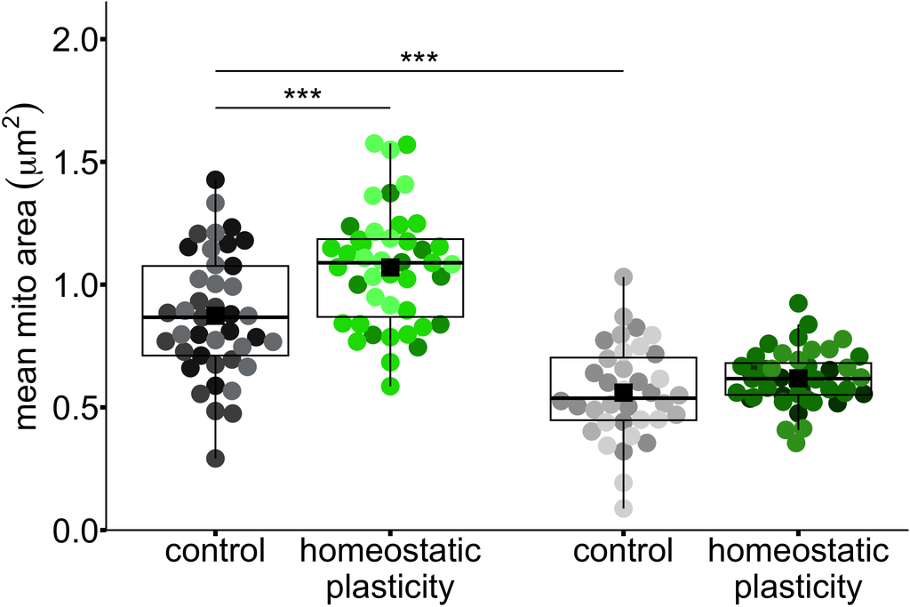

```r
set.seed(20261109)
test_results <- comparison_results %>%
  filter(!(group1 == "Juxta TTX" & group2 == "Non Juxta TTX")) %>%
  mutate(group1_x = unname(spacing_map[group1]), group2_x = unname(spacing_map[group2]),
         y_position = case_when(group1 == "Juxta Control" & group2 == "Non Juxta Control" ~ 1.87,
                                TRUE ~ 1.72),
         stars = p_to_stars(p_value)) %>% filter(stars != "ns")
date_levels <- levels(mito_df$date)
group_date_colors <- c(
  setNames(rep(c("#1A1A1A", "#4D4D4D", "#777B7E"), length.out = length(date_levels)), paste("Juxta Control", date_levels, sep = "_")),
  setNames(rep(c("#009A00", "#00DC00", "#66FF66"), length.out = length(date_levels)), paste("Juxta TTX", date_levels, sep = "_")),
  setNames(rep(c("#9E9E9E", "#BDBDBD", "#D9D9D9"), length.out = length(date_levels)), paste("Non Juxta Control", date_levels, sep = "_")),
  setNames(rep(c("#003D00", "#008000", "#3A9D23"), length.out = length(date_levels)), paste("Non Juxta TTX", date_levels, sep = "_"))
)
fig1f_plot <- ggplot(mito_df, aes(x_pos, mito_area_um2, color = group_date)) +
  ggbeeswarm::geom_beeswarm(cex = 3, priority = "random", size = 20, corral = "random") +
  geom_boxplot(aes(group = x_pos), fill = NA, width = 1, outlier.shape = NA, linewidth = 2, color = "black") +
  stat_summary(aes(group = x_pos), fun = mean, geom = "point", shape = 15, size = 20, color = "black") +
  geom_segment(data = test_results, aes(x = group1_x, xend = group2_x, y = y_position, yend = y_position),
               inherit.aes = FALSE, color = "black", linewidth = 2) +
  geom_text(data = test_results, aes(x = (group1_x + group2_x) / 2, y = y_position + 0.03, label = stars),
            inherit.aes = FALSE, color = "black", size = 28) +
  scale_color_manual(values = group_date_colors) +
  scale_x_continuous(breaks = unname(spacing_map),
                     labels = c("control", "homeostatic\nplasticity", "control", "homeostatic\nplasticity")) +
  scale_y_continuous(oob = scales::oob_keep, breaks = c(0, 0.5, 1, 1.5, 2), limits = c(0, 2.15), expand = c(0, 0)) +
  labs(x = NULL, y = expression(mean~mito~area~group("(", mu*m^2, ")"))) + figure_theme()
fig1f_plot
```

# Fig 1G

Juxtaspinal mitochondrial area during the first 24 hours of homeostatic plasticity.

**Source data**  
`Fig 1G.csv`

**Columns**

- `date` — Experiment date
- `condition` — Control or TTX
- `dish` — Culture dish ID
- `cell` — Cell ID
- `spine` — Spine ID
- `track_id` — Tracked mitochondrial region ID
- `mito_area_um2` — Mitochondrial area (µm²)
- `norm_mito_area` — Baseline-normalized mitochondrial area (unitless)
- `time_hr` — Time relative to treatment (h)

## Data

The analysis covers −0.25 to 24 h. Tests use raw area, and the plot shows area relative to baseline.

```r
condition_order <- c("Control", "TTX")
Mito <- read_csv("./Fig 1G.csv", show_col_types = FALSE) %>%
  mutate(condition = factor(condition, levels = condition_order), track_id = as.character(track_id),
         across(c(time_hr, mito_area_um2, norm_mito_area), as.numeric)) %>%
  filter(!is.na(condition), !is.na(track_id), track_id != "",
         is.finite(time_hr), time_hr >= -0.25, time_hr <= 24)
Mito %>% mutate(across(where(is.numeric), ~ round(.x, 3)))
```

| date | condition | dish | cell | spine | track_id | spine_area_um2 | mito_area_um2 | norm_spine_area | norm_mito_area | time_hr |
| --- | --- | --- | --- | --- | --- | --- | --- | --- | --- | --- |
| 2026-06-02 | TTX | 1 | 1 | 1 | 2026-06-02 TTX Dish1 Cell1 Spine1 | 0.301 | 0.973 | 1.000 | 1.000 | -0.25 |
| 2026-06-02 | TTX | 1 | 1 | 1 | 2026-06-02 TTX Dish1 Cell1 Spine1 | 0.301 | 1.555 | 1.000 | 1.598 | 0.00 |
| 2026-06-02 | TTX | 1 | 1 | 1 | 2026-06-02 TTX Dish1 Cell1 Spine1 | 0.361 | 1.425 | 1.200 | 1.464 | 1.00 |
| 2026-06-02 | TTX | 1 | 1 | 1 | 2026-06-02 TTX Dish1 Cell1 Spine1 | 0.341 | 1.515 | 1.133 | 1.557 | 2.00 |
| 2026-06-02 | TTX | 1 | 1 | 1 | 2026-06-02 TTX Dish1 Cell1 Spine1 | 0.311 | 1.555 | 1.033 | 1.598 | 3.00 |
| 2026-06-02 | TTX | 1 | 1 | 1 | 2026-06-02 TTX Dish1 Cell1 Spine1 | 0.361 | 0.311 | 1.200 | 0.320 | 4.00 |
| 2026-06-02 | TTX | 1 | 1 | 1 | 2026-06-02 TTX Dish1 Cell1 Spine1 | 0.381 | 0.472 | 1.267 | 0.485 | 5.00 |
| 2026-06-02 | TTX | 1 | 1 | 1 | 2026-06-02 TTX Dish1 Cell1 Spine1 | 0.291 | 1.435 | 0.967 | 1.474 | 6.00 |
| 2026-06-02 | TTX | 1 | 1 | 1 | 2026-06-02 TTX Dish1 Cell1 Spine1 | 0.421 | 1.565 | 1.400 | 1.608 | 7.00 |
| 2026-06-02 | TTX | 1 | 1 | 1 | 2026-06-02 TTX Dish1 Cell1 Spine1 | 0.371 | 1.706 | 1.233 | 1.753 | 8.00 |

[output cut: 3412 more lines]

## Summary

```r
summary_table <- Mito %>% group_by(condition) %>%
  summarise(n_spines = n_distinct(track_id), n_Experiment_Dates = n_distinct(date), .groups = "drop")
summary_table
```

| condition | n_spines | n_Experiment_Dates |
| --- | --- | --- |
| Control | 90 | 3 |
| TTX | 77 | 3 |

## Statistics

Repeated-measures ANOVA within condition on raw area, with Greenhouse–Geisser correction and Tukey-adjusted period comparisons.

```r
block_levels <- c("Baseline", "Post1", "Post2")
block_ranges <- c(Baseline = "-0.25", Post1 = "0-11", Post2 = "12-24")
block_data <- Mito %>%
  mutate(time_block = case_when(time_hr == -0.25 ~ "Baseline", time_hr >= 0 & time_hr <= 11 ~ "Post1",
                                time_hr >= 12 & time_hr <= 24 ~ "Post2")) %>%
  filter(!is.na(time_block), is.finite(mito_area_um2)) %>%
  group_by(condition, track_id, time_block) %>%
  summarise(mito_area_um2 = mean(mito_area_um2), .groups = "drop") %>%
  mutate(time_block = factor(time_block, levels = block_levels))
stats_results <- list()
for (condition_name in condition_order) {
  condition_data <- block_data %>% filter(condition == condition_name) %>% select(track_id, time_block, mito_area_um2)
  complete_ids <- condition_data %>% count(track_id) %>% filter(n == 3) %>% pull(track_id)
  condition_data <- condition_data %>% filter(track_id %in% complete_ids) %>% mutate(track_id = factor(track_id))
  if (n_distinct(condition_data$track_id) < 2) next
  rm_aov <- suppressMessages(afex::aov_ez(id = "track_id", dv = "mito_area_um2", within = "time_block",
                                         data = condition_data, anova_table = list(correction = "GG")))
  emmeans_table <- emmeans::emmeans(rm_aov, ~ time_block)
  means <- as.data.frame(emmeans_table)
  comparisons <- as.data.frame(emmeans::contrast(emmeans_table, "pairwise", adjust = "tukey")) %>%
    filter(grepl("^Baseline - ", contrast)) %>% mutate(compared_block = sub("^Baseline - ", "", contrast))
  baseline_index <- match("Baseline", means$time_block)
  block_index <- match(comparisons$compared_block, means$time_block)
  stats_results[[condition_name]] <- tibble(
    condition = condition_name, compared_block = comparisons$compared_block,
    `Baseline mean (SE)` = sprintf("%.3f (%.3f)", means$emmean[baseline_index], means$SE[baseline_index]),
    `Compared mean (SE)` = sprintf("%.3f (%.3f)", means$emmean[block_index], means$SE[block_index]),
    anova_p = as.numeric(rm_aov$anova_table[["Pr(>F)"]][1]), p_value = comparisons$p.value
  )
}
posthoc_df <- bind_rows(stats_results)
if (nrow(posthoc_df) == 0) stop("No condition had at least two complete tracks.")
stats_table <- posthoc_df %>% transmute(
  condition, Test = "Repeated-measures ANOVA with Tukey post hoc",
  Comparison = paste(block_ranges["Baseline"], "vs", block_ranges[compared_block]),
  `Baseline mean (SE)`, `Compared mean (SE)`,
  `ANOVA p` = format_p(anova_p), `Tukey p` = format_p(p_value)
)
stats_table
```

| condition | Test | Comparison | Baseline mean (SE) | Compared mean (SE) | ANOVA p | Tukey p |
| --- | --- | --- | --- | --- | --- | --- |
| Control | Repeated-measures ANOVA with Tukey post hoc | -0.25 vs 0-11 | 1.107 (0.025) | 0.976 (0.028) | <0.0001 | <0.0001 |
| Control | Repeated-measures ANOVA with Tukey post hoc | -0.25 vs 12-24 | 1.107 (0.025) | 1.071 (0.028) | <0.0001 | 0.4215 |
| TTX | Repeated-measures ANOVA with Tukey post hoc | -0.25 vs 0-11 | 1.092 (0.042) | 1.140 (0.041) | <0.0001 | 0.2948 |
| TTX | Repeated-measures ANOVA with Tukey post hoc | -0.25 vs 12-24 | 1.092 (0.042) | 1.264 (0.046) | <0.0001 | <0.0001 |

## Plot

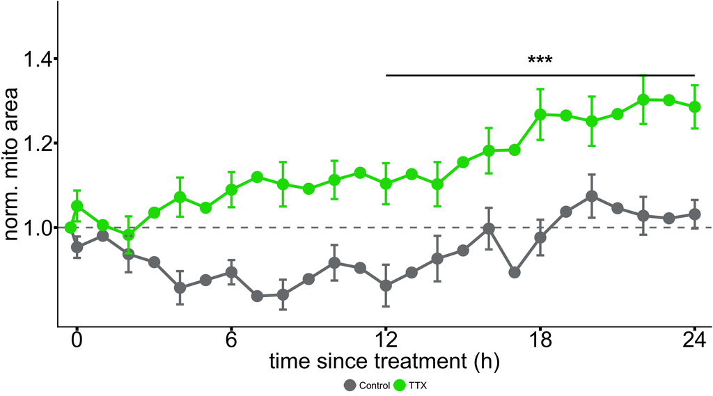

```r
set.seed(20261109)
condition_colors <- c("Control" = "#777B7E", "TTX" = "#00DC00")
stat_y <- c("Control" = 1.44, "TTX" = 1.36)
norm_summary <- Mito %>% mutate(time_order = match(time_hr, sort(unique(time_hr)))) %>%
  group_by(condition, time_hr, time_order) %>%
  summarise(mean_value = mean(norm_mito_area, na.rm = TRUE), sd = sd(norm_mito_area, na.rm = TRUE),
            n = sum(is.finite(norm_mito_area)), sem = sd / sqrt(n), .groups = "drop") %>%
  filter(n > 0, is.finite(mean_value))
errorbars <- norm_summary %>% filter(time_order %% 2 == 0, is.finite(sem))
annotations <- posthoc_df %>% filter(compared_block == "Post2", p_value < 0.05) %>%
  mutate(x_start = 12, x_end = 24, x_label = 18,
         y = unname(stat_y[condition]), stars = p_to_stars(p_value))
norm_plot <- ggplot(norm_summary, aes(time_hr, mean_value, color = condition, group = condition)) +
  geom_hline(yintercept = 1, color = "grey50", linetype = "dashed", linewidth = 3) +
  geom_line(linewidth = 5) + geom_point(size = 20) +
  geom_errorbar(data = errorbars, aes(ymin = mean_value - sem, ymax = mean_value + sem), width = 0.3, linewidth = 4) +
  geom_segment(data = annotations, aes(x = x_start, xend = x_end, y = y, yend = y),
               inherit.aes = FALSE, color = "black", linewidth = 3) +
  geom_text(data = annotations, aes(x = x_label, y = y, label = stars),
            inherit.aes = FALSE, color = "black", vjust = -0.3, size = 28, fontface = "bold") +
  scale_color_manual(values = condition_colors, breaks = condition_order) +
  scale_x_continuous(breaks = c(0, 6, 12, 18, 24), expand = expansion(add = c(0.5, 0.5))) +
  scale_y_continuous(oob = scales::oob_keep, limits = c(0.8, 1.5), breaks = c(1.0, 1.2, 1.4)) +
  labs(x = "time since treatment (h)", y = "norm. mito area") + figure_theme() +
  theme(legend.position="bottom",legend.text=element_text(size=35),legend.title=element_blank())
norm_plot
```

# Fig 1I

Association of local spine size and juxtaspinal mitochondrial volume in mouse somatosensory cortex.

**update for 2026 pending** — The current analysis includes 112,246 synapses. The v3 legend reports 87,551.

**Source data**  
`Fig 1I.csv`

**Columns**

- `neuron_id` — Neuron ID
- `synapse_id` — Synapse ID
- `cluster_id` — Spine cluster ID
- `mito_vol_um3` — Juxtaspinal mitochondrial volume (µm³)
- `synapse_area_um2` — Synapse area (µm²)

## Data

Synapse areas are summed within clusters. Cluster totals and local mitochondrial volumes are averaged within neurons with more than 50 clusters. Mean cluster synapse area is log₁₀-transformed.

```r
MIN_CLUSTERS_PER_NEURON <- 50
raw_df <- read_csv("./Fig 1I.csv", col_types = cols(neuron_id = col_character(),
                   cluster_id = col_character(), synapse_id = col_character()), show_col_types = FALSE) %>%
  transmute(neuron_id = normalize_id(neuron_id), cluster_id = normalize_id(cluster_id),
            synapse_id = normalize_id(synapse_id), synapse_area_um2 = as.numeric(synapse_area_um2),
            mito_vol_um3 = as.numeric(mito_vol_um3)) %>%
  filter(!is.na(neuron_id), !is.na(cluster_id), !is.na(synapse_id))
if (nrow(raw_df) == 0) stop("No rows remain after removing missing identifiers.")

conflicting_synapses <- raw_df %>% group_by(neuron_id, cluster_id, synapse_id) %>%
  summarise(n_area_values = n_distinct(synapse_area_um2[is.finite(synapse_area_um2)]), .groups = "drop") %>%
  filter(n_area_values > 1)
if (nrow(conflicting_synapses) > 0) stop(nrow(conflicting_synapses), " synapses have multiple synapse-area values.")

synapse_df <- raw_df %>% group_by(neuron_id, cluster_id, synapse_id) %>%
  summarise(synapse_area_um2 = first(synapse_area_um2[is.finite(synapse_area_um2)], default = NA_real_),
            mito_vol_um3 = if (any(is.finite(mito_vol_um3))) mean(mito_vol_um3[is.finite(mito_vol_um3)]) else NA_real_,
            .groups = "drop")
conflicting_clusters <- synapse_df %>% filter(is.finite(mito_vol_um3)) %>% group_by(neuron_id, cluster_id) %>%
  summarise(mito_range = max(mito_vol_um3) - min(mito_vol_um3), .groups = "drop") %>% filter(mito_range > 1e-12)
if (nrow(conflicting_clusters) > 0) stop(nrow(conflicting_clusters), " clusters have multiple mitochondrial-volume values.")

cluster_df <- synapse_df %>% group_by(neuron_id, cluster_id) %>%
  summarise(total_synapse_area_um2 = if (any(is.finite(synapse_area_um2))) sum(synapse_area_um2[is.finite(synapse_area_um2)]) else NA_real_,
            mito_vol_um3 = if (any(is.finite(mito_vol_um3))) mean(mito_vol_um3[is.finite(mito_vol_um3)]) else NA_real_,
            total_synapses = n_distinct(synapse_id), .groups = "drop")
retained_neurons <- cluster_df %>% count(neuron_id, name = "total_clusters") %>%
  filter(total_clusters > MIN_CLUSTERS_PER_NEURON) %>% pull(neuron_id)
if (length(retained_neurons) == 0) stop("No neurons have more than ", MIN_CLUSTERS_PER_NEURON, " clusters.")
cluster_df <- cluster_df %>%
  filter(neuron_id %in% retained_neurons, is.finite(total_synapse_area_um2), total_synapse_area_um2 > 0,
         is.finite(mito_vol_um3), mito_vol_um3 >= 0)
analysis_df <- cluster_df %>% group_by(neuron_id) %>%
  summarise(total_synapse_area_um2 = mean(total_synapse_area_um2), mito_vol_um3 = mean(mito_vol_um3),
            clusters_in_average = n_distinct(cluster_id), total_synapses = sum(total_synapses), .groups = "drop") %>%
  mutate(plot_synapse_area = log10(total_synapse_area_um2)) %>%
  filter(is.finite(plot_synapse_area), is.finite(mito_vol_um3))
if (nrow(analysis_df) < 3) stop("At least three data points are required.")
if (n_distinct(analysis_df$plot_synapse_area) < 2) stop("All x-values are identical.")
analysis_df %>% mutate(across(where(is.numeric), ~ round(.x, 3)))
```

| neuron_id | total_synapse_area_um2 | mito_vol_um3 | clusters_in_average | total_synapses | plot_synapse_area |
| --- | --- | --- | --- | --- | --- |
| 1012805 | 0.952 | 0.132 | 54 | 145 | -0.021 |
| 103867 | 0.655 | 0.068 | 59 | 100 | -0.184 |
| 10401 | 0.886 | 0.131 | 65 | 155 | -0.053 |
| 1042 | 1.059 | 0.122 | 235 | 487 | 0.025 |
| 105151 | 0.768 | 0.107 | 202 | 433 | -0.115 |
| 105158 | 1.114 | 0.129 | 195 | 364 | 0.047 |
| 105217 | 0.548 | 0.082 | 82 | 126 | -0.261 |
| 105333 | 0.818 | 0.163 | 80 | 174 | -0.087 |
| 105460 | 0.694 | 0.124 | 81 | 163 | -0.159 |
| 1057940 | 0.693 | 0.102 | 65 | 142 | -0.159 |

[output cut: 379 more lines]

## Summary

```r
summary_table <- tibble(n_neurons = n_distinct(analysis_df$neuron_id),
                       n_clusters = nrow(distinct(cluster_df, neuron_id, cluster_id)),
                       n_synapses = nrow(semi_join(synapse_df, cluster_df, by=c("neuron_id","cluster_id"))))
summary_table
```

| n_neurons | n_clusters | n_synapses |
| --- | --- | --- |
| 389 | 50387 | 112246 |

## Statistics

Two-sided Pearson correlation across neurons. The fitted line shows the 95% confidence band.

```r
correlation_test <- cor.test(analysis_df$plot_synapse_area, analysis_df$mito_vol_um3, method = "pearson")
pearson_r <- unname(correlation_test$estimate)
p_value <- correlation_test$p.value
stats_table <- tibble(Test = "Pearson correlation",
                      Variables = "Log10 mean synapse area vs mean mitochondrial volume",
                      n = nrow(analysis_df), `Pearson r` = sprintf("%.3f", pearson_r), `p value` = format_p(p_value))
stats_table
```

| Test | Variables | n | Pearson r | p value |
| --- | --- | --- | --- | --- |
| Pearson correlation | Log10 mean synapse area vs mean mitochondrial volume | 389 | 0.629 | <0.0001 |

## Plot

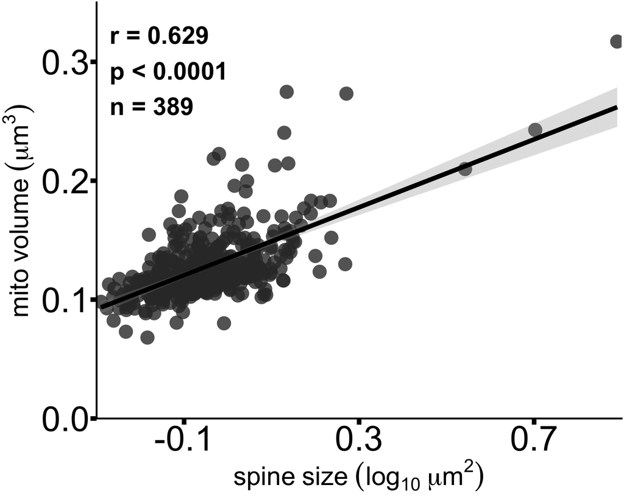

```r
set.seed(20261109)
stats_label <- paste0("r = ", sprintf("%.3f", pearson_r),
                      "\np ", ifelse(p_value < 0.0001, "< 0.0001", paste0("= ", sprintf("%.4f", p_value))),
                      "\nn = ", nrow(analysis_df))
fig1i_plot <- ggplot(analysis_df, aes(plot_synapse_area, mito_vol_um3)) +
  geom_point(shape = 16, size = 15, alpha = 0.8, color = "grey20") +
  geom_smooth(method = "lm", formula = y ~ x, se = TRUE, level = 0.95,
              color = "black", fill = "grey60", linewidth = 5, alpha = 0.3) +
  annotate("text", x = -0.27, y = 0.33, label = stats_label,
           hjust = 0, vjust = 1, size = 20, color = "black", fontface = "bold") +
  scale_x_continuous(oob = scales::oob_keep, breaks = c(-0.1, 0.3, 0.7), limits = c(-0.3, 0.9), expand = c(0, 0)) +
  scale_y_continuous(oob = scales::oob_keep, breaks = c(0, 0.1, 0.2, 0.3), limits = c(0, 0.35), expand = c(0, 0)) +
  labs(x = expression(spine~size~(log[10]~mu*m^2)), y = expression(mito~volume~(mu*m^3))) +
  figure_theme(60, 80)
fig1i_plot
```

# Fig 1J

Association of local spine size and juxtaspinal mitochondrial volume in the visual cortex connectomics dataset.

**update for 2026 pending** — The current analysis gives 348 neurons and r = 0.581. The v3 legend reports 310 neurons and r = 0.66.

**Source data**  
`Fig 1J.csv.gz`

**Columns**

- `neuron_id` — Neuron ID
- `synapse_id` — Synapse ID
- `cluster_id` — Spine cluster ID
- `cleft_vol_um3` — Synaptic cleft volume (µm³)
- `mito_vol_um3` — Juxtaspinal mitochondrial volume (µm³)

## Data

Synaptic cleft volumes are summed within clusters. Clusters with incomplete cleft measurements are excluded. Cluster totals and local mitochondrial volumes are averaged within neurons with more than 50 source clusters.

```r
MIN_CLUSTERS_PER_NEURON <- 50
X_MULTIPLIER <- 1000
Y_MULTIPLIER <- 10
raw_df <- read_csv("./Fig 1J.csv.gz", col_types = cols(neuron_id = col_character(),
                   cluster_id = col_character(), synapse_id = col_character()), show_col_types = FALSE) %>%
  transmute(neuron_id = normalize_id(neuron_id), cluster_id = normalize_id(cluster_id),
            synapse_id = normalize_id(synapse_id), cleft_vol_um3 = as.numeric(cleft_vol_um3),
            mito_vol_um3 = as.numeric(mito_vol_um3)) %>%
  filter(!is.na(neuron_id), !is.na(cluster_id), !is.na(synapse_id))
if (nrow(raw_df) == 0) stop("No rows remain after removing missing identifiers.")

conflicting_synapses <- raw_df %>% group_by(neuron_id, cluster_id, synapse_id) %>%
  summarise(n_cleft_values = n_distinct(cleft_vol_um3[is.finite(cleft_vol_um3)]), .groups = "drop") %>%
  filter(n_cleft_values > 1)
if (nrow(conflicting_synapses) > 0) stop(nrow(conflicting_synapses), " synapses have multiple cleft-volume values.")
synapse_df <- raw_df %>% group_by(neuron_id, cluster_id, synapse_id) %>%
  summarise(cleft_vol_um3 = first(cleft_vol_um3[is.finite(cleft_vol_um3)], default = NA_real_),
            mito_vol_um3 = if (any(is.finite(mito_vol_um3))) mean(mito_vol_um3[is.finite(mito_vol_um3)]) else NA_real_,
            .groups = "drop")
conflicting_clusters <- synapse_df %>% filter(is.finite(mito_vol_um3)) %>% group_by(neuron_id, cluster_id) %>%
  summarise(mito_range = max(mito_vol_um3) - min(mito_vol_um3), .groups = "drop") %>% filter(mito_range > 1e-12)
if (nrow(conflicting_clusters) > 0) stop(nrow(conflicting_clusters), " clusters have multiple mitochondrial-volume values.")

cluster_df <- synapse_df %>% group_by(neuron_id, cluster_id) %>%
  summarise(total_cleft_vol_um3 = if (any(is.finite(cleft_vol_um3))) sum(cleft_vol_um3, na.rm = TRUE) else NA_real_,
            mito_vol_um3 = if (any(is.finite(mito_vol_um3))) mean(mito_vol_um3[is.finite(mito_vol_um3)]) else NA_real_,
            total_synapses = n_distinct(synapse_id), measured_synapses = sum(is.finite(cleft_vol_um3)),
            .groups = "drop") %>% mutate(missing_cleft = total_synapses - measured_synapses)
retained_neurons <- cluster_df %>% count(neuron_id, name = "total_clusters") %>%
  filter(total_clusters > MIN_CLUSTERS_PER_NEURON) %>% pull(neuron_id)
if (length(retained_neurons) == 0) stop("No neurons have more than ", MIN_CLUSTERS_PER_NEURON, " clusters.")
cluster_df <- cluster_df %>%
  filter(neuron_id %in% retained_neurons, missing_cleft == 0,
         is.finite(total_cleft_vol_um3), total_cleft_vol_um3 > 0,
         is.finite(mito_vol_um3), mito_vol_um3 >= 0)
if (nrow(cluster_df) == 0) stop("No valid cluster measurements remain.")
analysis_df <- cluster_df %>% group_by(neuron_id) %>%
  summarise(total_cleft_vol_um3 = mean(total_cleft_vol_um3) * X_MULTIPLIER,
            mito_vol_um3 = mean(mito_vol_um3) * Y_MULTIPLIER,
            clusters_in_average = n_distinct(cluster_id), total_synapses = sum(total_synapses), .groups = "drop") %>%
  mutate(plot_cleft_volume = total_cleft_vol_um3) %>%
  filter(is.finite(plot_cleft_volume), is.finite(mito_vol_um3))
if (nrow(analysis_df) < 3) stop("At least three data points are required.")
if (n_distinct(analysis_df$plot_cleft_volume) < 2) stop("All x-values are identical.")
analysis_df %>% mutate(across(where(is.numeric), ~ round(.x, 3)))
```

| neuron_id | total_cleft_vol_um3 | mito_vol_um3 | clusters_in_average | total_synapses | plot_cleft_volume |
| --- | --- | --- | --- | --- | --- |
| 648518346349491311 | 0.731 | 0.253 | 482 | 1666 | 0.731 |
| 648518346349492130 | 0.756 | 0.307 | 254 | 893 | 0.756 |
| 648518346349492197 | 1.148 | 0.284 | 360 | 1469 | 1.148 |
| 648518346349492682 | 1.113 | 0.403 | 298 | 1279 | 1.113 |
| 648518346349493487 | 1.310 | 0.490 | 173 | 889 | 1.310 |
| 648518346349494004 | 0.908 | 0.254 | 164 | 753 | 0.908 |
| 648518346349494577 | 0.937 | 0.392 | 181 | 900 | 0.937 |
| 648518346349496405 | 0.999 | 0.443 | 600 | 2550 | 0.999 |
| 648518346349503588 | 1.048 | 0.487 | 506 | 2253 | 1.048 |
| 648518346349505739 | 1.128 | 0.346 | 344 | 1938 | 1.128 |

[output cut: 338 more lines]

## Summary

```r
summary_table <- tibble(n_neurons = n_distinct(analysis_df$neuron_id),
                       n_clusters = nrow(distinct(cluster_df, neuron_id, cluster_id)),
                       n_synapses = sum(cluster_df$total_synapses))
summary_table
```

| n_neurons | n_clusters | n_synapses |
| --- | --- | --- |
| 348 | 184349 | 856552 |

## Statistics

Two-sided Pearson correlation across neurons. The fitted line shows the 95% confidence band.

```r
correlation_test <- cor.test(analysis_df$plot_cleft_volume, analysis_df$mito_vol_um3, method = "pearson")
pearson_r <- unname(correlation_test$estimate)
p_value <- correlation_test$p.value
stats_table <- tibble(Test = "Pearson correlation",
                      Variables = "Mean synaptic cleft volume vs mean mitochondrial volume",
                      n = nrow(analysis_df), `Pearson r` = sprintf("%.3f", pearson_r), `p value` = format_p(p_value))
stats_table
```

| Test | Variables | n | Pearson r | p value |
| --- | --- | --- | --- | --- |
| Pearson correlation | Mean synaptic cleft volume vs mean mitochondrial volume | 348 | 0.581 | <0.0001 |

## Plot

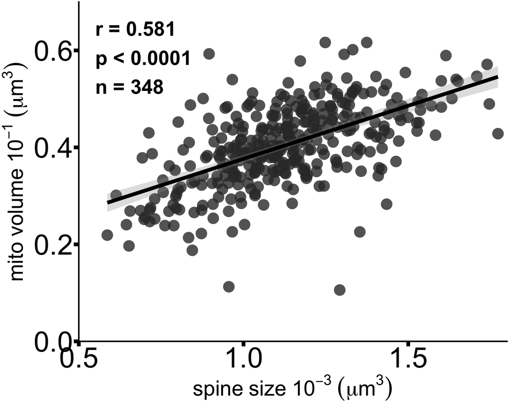

```r
set.seed(20261109)
stats_label <- paste0("r = ", sprintf("%.3f", pearson_r),
                      "\np ", ifelse(p_value < 0.0001, "< 0.0001", paste0("= ", sprintf("%.4f", p_value))),
                      "\nn = ", nrow(analysis_df))
fig1j_plot <- ggplot(analysis_df, aes(plot_cleft_volume, mito_vol_um3)) +
  geom_point(shape = 16, size = 15, alpha = 0.8, color = "grey20") +
  geom_smooth(method = "lm", formula = y ~ x, se = TRUE, level = 0.95,
              color = "black", fill = "grey60", linewidth = 5, alpha = 0.3) +
  annotate("text", x = 0.55, y = 0.66, label = stats_label,
           hjust = 0, vjust = 1, size = 20, color = "black", fontface = "bold") +
  scale_x_continuous(oob = scales::oob_keep, breaks = c(0.5, 1, 1.5, 2), limits = c(0.5, 1.8), expand = c(0, 0)) +
  scale_y_continuous(oob = scales::oob_keep, breaks = c(0, 0.2, 0.4, 0.6), limits = c(0, 0.7), expand = c(0, 0)) +
  labs(x = expression(spine~size~10^{-3}~group("(", mu*m^3, ")")),
       y = expression(mito~volume~10^{-1}~group("(", mu*m^3, ")"))) + figure_theme(60, 80)
fig1j_plot
```